# Scraping and visualizing Indian election data with rvest, dplyr, and ggplot2

Kyle Walker (@kyle_e_walker)

October 21, 2014

I’ve been working on a project to show the differences between the Indian Lok Sabha elections of 2014, in which the Bharatiya Janata Party (BJP) won a resounding victory, and the 2009 elections, where the Indian National Congress (INC) won the most seats. I’ve been trying to think through the best ways to visualize the data, and have found a lot of options. I follow many of the top data scientists and dataviz experts on Twitter, and try to incorporate their insights as best as I can into my work. However, there is not always a consensus on the “best” chart type to use (aside from a universal disdain for pie charts). For example, [while some prefer bar charts](https://twitter.com/oceankidbilly/status/523162269253775360), [others are more skeptical](http://solomonmessing.wordpress.com/2012/03/04/visualization-series-insight-from-cleveland-and-tufte-on-plotting-numeric-data-by-groups/).

I opted for a compromise between a bar and dot plot; I’ll show how I did this below. To get started, I used the new **rvest** package to scrape data on the distribution of Lok Sabha seats by party from Wikipedia, and used **dplyr** to get it into the necessary format for visualization.

```r
library(dplyr)
library(rvest)
library(ggplot2)

url09 <- html("http://en.wikipedia.org/wiki/Results_of_the_2009_Indian_general_election_by_party")

url14 <- html("http://en.wikipedia.org/wiki/Results_of_the_Indian_general_election,_2014")

tbls09 <- html_nodes(url09, "table")

tbls14 <- html_nodes(url14, "table")

df09 <- data.frame(html_table(tbls09[2]))

df14 <- data.frame(html_table(tbls14[3], fill = TRUE))

df09 <- df09 %>%
  select(party = Party, seats = Seats.No.) %>%
  filter(party != "Total", !is.na(seats)) %>%
  mutate(party2 = ifelse(min_rank(desc(seats)) < 11, party, "Other")) %>%
  group_by(party2) %>%
  summarize(seats2 = sum(seats)) %>%
  mutate(party2 = gsub("Shivsena", "Shiv Sena", party2)) %>%
  arrange(desc(seats2))

df14 <- df14 %>%
  select(party = NA., seats = Seats) %>%
  filter(party != "Total", seats > 0) %>%
  mutate(party2 = ifelse(min_rank(desc(seats)) < 11, party, "Other")) %>%
  group_by(party2) %>%
  summarize(seats2 = sum(seats)) %>%
  mutate(party2 = gsub("All India Anna Dravida Munnetra Kazhagam", "All India ADMK", party2)) %>%
  arrange(desc(seats2))
```

I now have tables showing the parties who won the most seats in the Lok Sabha in the 2009 and 2014 elections, with minor parties grouped together as “Other.” I’ll now visualize the data with **ggplot2**. I’ve chosen to make something resembling a [Cleveland dot plot](http://en.wikipedia.org/wiki/Dot_plot_%28statistics%29#Cleveland_dot_plots), with a line showing the size of the group. Colors on the plot reflect the colors of the Indian parties.

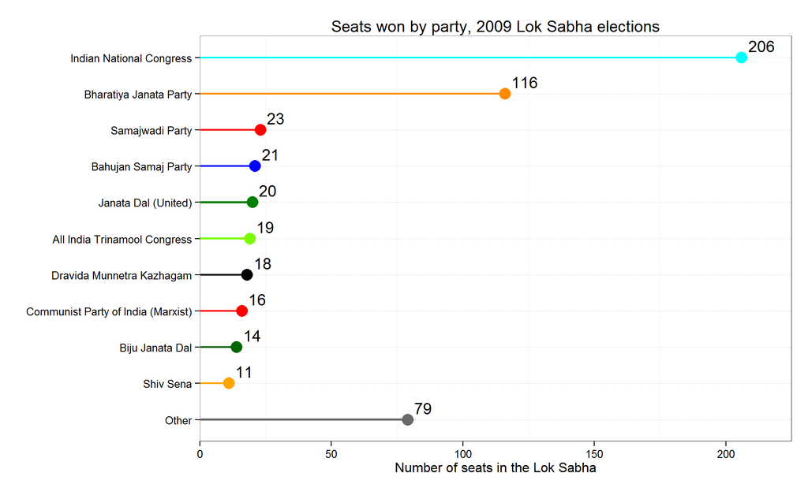

```r
v9 <- c("Indian National Congress", "Bharatiya Janata Party",
        "Samajwadi Party", "Bahujan Samaj Party", "Janata Dal (United)",
        "All India Trinamool Congress", "Dravida Munnetra Kazhagam",
        "Communist Party of India (Marxist)", "Biju Janata Dal", "Shiv Sena", "Other")


colors09 <- c("#00FFFF", "#FF8C00", "#FF0000", "#0000FF", "#008000",
              "#7CFC00", "#000000", "#FF0000", "#006400", "#FFA500", "#696969")

df09$factor <- factor(df09$party2, levels = rev(v9), labels = rev(v9))

g9 <- ggplot(df09) +
  geom_point(aes(x = factor, y = seats2, color = factor), stat = "identity", size = 5) +
  geom_text(aes(x = factor, y = seats2 + 2.5, label = seats2), hjust = 0, vjust = -0.5) +
  geom_bar(aes(x = factor, y = seats2, fill = factor), stat = "identity", width = 0.05) +
  coord_flip() +
  theme_bw() +
  labs(list(y = "Number of seats in the Lok Sabha", x = "")) +
  theme(panel.grid.major.x = element_blank(),
        panel.grid.major.y = element_line(linetype=3, color="darkgray"),
        legend.position = "none") +
  scale_y_continuous(expand = c(0, 0), limits = c(0, 225)) +
  scale_color_manual(values = rev(colors09)) +
  scale_fill_manual(values = rev(colors09)) +
  ggtitle("Seats won by party, 2009 Lok Sabha elections")

g9
```

I now can do the same things for the 2014 elections, which show the large gains by the BJP, and the losses by the INC, when looked at in relationship to the 2009 chart.

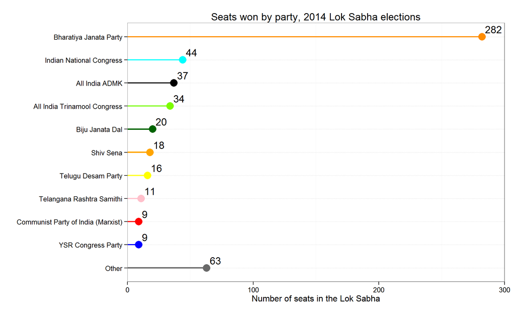

```r
v14 <- c("Bharatiya Janata Party", "Indian National Congress",
         "All India ADMK", "All India Trinamool Congress",
         "Biju Janata Dal", "Shiv Sena", "Telugu Desam Party", "Telangana Rashtra Samithi",
         "Communist Party of India (Marxist)", "YSR Congress Party", "Other")

colors14 <- c("#FF8C00", "#00FFFF", "#000000", "#7CFC00", "#006400",
              "#FFA500", "#FFFF00", "#FFC0CB", "#FF0000", "#0000FF", "#696969")

df14$factor <- factor(df14$party2, levels = rev(v14), labels = rev(v14))


g14 <- ggplot(df14) +
  geom_point(aes(x = factor, y = seats2, color = factor), stat = "identity", size = 5) +
  geom_text(aes(x = factor, y = seats2 + 2.5, label = seats2), hjust = 0, vjust = -0.5) +
  geom_bar(aes(x = factor, y = seats2, fill = factor), stat = "identity", width = 0.05) +
  coord_flip() +
  theme_bw() +
  labs(list(y = "Number of seats in the Lok Sabha", x = "")) +
  theme(panel.grid.major.x = element_blank(),
        panel.grid.major.y = element_line(linetype=3, color="darkgray"),
        legend.position = "none") +
  scale_y_continuous(expand = c(0, 0), limits = c(0, 300)) +
  scale_color_manual(values = rev(colors14)) +
  scale_fill_manual(values = rev(colors14)) +
  ggtitle("Seats won by party, 2014 Lok Sabha elections")

g14
```

These charts have accomplished what I was looking for - however, I know there are many other ways I could have done this. If you have any thoughts, let me know! I’m available on [Twitter](https://twitter.com/kyle_e_walker).